# Secuenciación de liga correo Fco

# SECUENCIACIÓN METAGENOMICA DADA2

```r
library(dada2)
```

```r
list.files(path)
```

```
 [1] "filtered"                  "M1_S188_L001_R1.fastq.gz"
 [3] "M1_S188_L001_R2.fastq.gz"  "M12_S191_L001_R1.fastq.gz"
 [5] "M12_S191_L001_R2.fastq.gz" "M15_S192_L001_R1.fastq.gz"
 [7] "M15_S192_L001_R2.fastq.gz" "M16_S193_L001_R1.fastq.gz"
 [9] "M16_S193_L001_R2.fastq.gz" "M5_S189_L001_R1.fastq.gz"
[11] "M5_S189_L001_R2.fastq.gz"  "M7_S190_L001_R1.fastq.gz"
[13] "M7_S190_L001_R2.fastq.gz"
```

# Revisión de perfil de Calidad

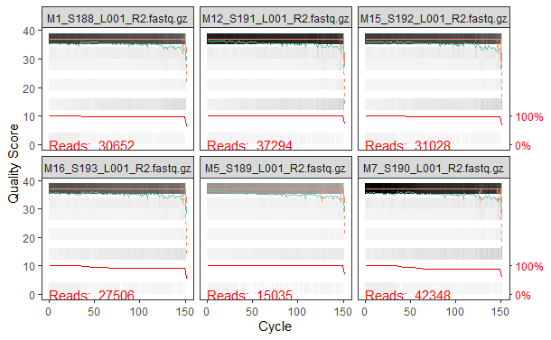

```r
# reverse
plotQualityProfile(fnRs[1:6])
```

# Filtrar y cortar

```r
# Guardando el camino a nuestras muestras filtadas en un objeto nuevo
filtFs <- file.path(path, "filtered", paste0(sample.names,  "_F_filt.fastq.gz")) # forward
filtRs <- file.path(path, "filtered", paste0(sample.names, "_R_filt.fastq.gz")) #reverse

# Asignando los nombres de las muestras a nuestros objetos nuevos
names(filtFs) <- sample.names
names(filtRs) <- sample.names
```

```r
# parametros de filtrado y cortado

out <- filterAndTrim(fnFs, filtFs, # forward reads
                     fnRs, filtRs, # reverse reads
                     truncLen = c(140,140), # truncado o corte
                     maxN = 0, # remover Ns, ESTE NUNCA SE PUEDE MODIFICAR
                     maxEE = c(5,5), #error esperado, lo estandar es 2,2
                     truncQ = 2, #quality score
                     rm.phix = TRUE, compress = TRUE, #defaults
                     multithread = FALSE) # en windows


out <- read.csv("~/RStudio/CursoInnovak/Agronomia/Materiales/Conteo_reads1.csv") # por si lo cierrar solo corres el objeto
```

```r
# forward
filtFs <- sort(list.files(path2, pattern = "_F_filt.fastq.gz",
                          full.names = TRUE))
```

```
Error: objeto 'path2' no encontrado
```

# Tasas de error

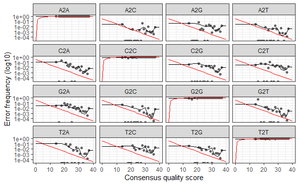

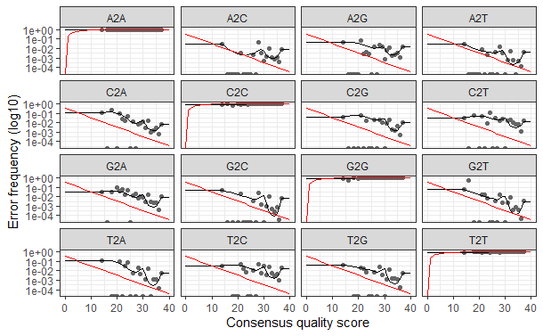

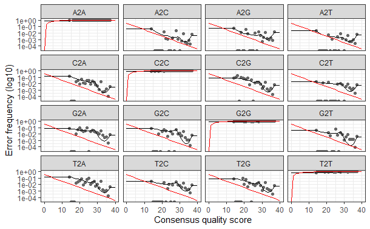

```r
##Plot error rates
plotErrors(errF, nominalQ = TRUE)
##Plot error rates
plotErrors(errF, nominalQ = TRUE)

plotErrors(errR, nominalQ = TRUE)
```

# Interferencia de las muestras, ruidos

```r
#Reverse
dadaRs_nopool <- dada(filtRs, err=errR, multithread = TRUE,
                      pool = FALSE)
```

```
Sample 1 - 29340 reads in 13070 unique sequences.
Sample 2 - 36843 reads in 21733 unique sequences.
Sample 3 - 30295 reads in 13995 unique sequences.
Sample 4 - 24753 reads in 10677 unique sequences.
Sample 5 - 14869 reads in 8748 unique sequences.
Sample 6 - 35960 reads in 18943 unique sequences.
```

# Unión de lecturas forward y reverse

```r
# parametros opcionales
mergers <- mergePairs(dadaFs_nopool, filtFs, dadaRs_nopool, filtRs,
                      verbose = TRUE,
                      minOverlap = 10, # tratar para ver si se incrementan las uniones
                      maxMismatch = 2, # el parametro default es 0, por lo que tiene que ser una union perfecta, no poner mas de 5
                      justConcatenate = TRUE, # une forward y pone NNNNX10 y luego une al reverse
                      returnRejects = TRUE) # nos muestra una tabla de reads rechazadas al momento de union, para ver si salen muchos mismatches incrementar el mismatch o si se estan uniendo muy poco cambiar en overlap. Se comenzaria con usar este parametro para ver que estamos perdiendo luego usamos mismatch, overlap y al final concatenate.
```

```
27633 paired-reads (in 2024 unique pairings) successfully merged out of 27633 (in 2024 pairings) input.
34375 paired-reads (in 3733 unique pairings) successfully merged out of 34375 (in 3733 pairings) input.
28613 paired-reads (in 2140 unique pairings) successfully merged out of 28613 (in 2140 pairings) input.
23080 paired-reads (in 1809 unique pairings) successfully merged out of 23080 (in 1809 pairings) input.
13556 paired-reads (in 1390 unique pairings) successfully merged out of 13556 (in 1390 pairings) input.
33394 paired-reads (in 3371 unique pairings) successfully merged out of 33394 (in 3371 pairings) input.
```

# Tabla de secuecias

```r
# Checar la longitud de todas las secuencias
table(nchar(getSequences(seqtab)))
```

```
169 171 172 173 174 175 176 177 178 179 180 181 182 183 184 185 186 187
  1 304 114  68  18   2 119  18   6   1   8   1   8   6   3   3   5   1
188 189 190 191 192 193 194 195 196 197 198 199
 23   3   3  18   4   2   1  40 139  30   4   1
```

# Quitar quimeras

```r
# Incluyendo abundancias
sum(seqtab.nochim)/sum(seqtab) # Tomando en cuenta abundancias en realidad mantuvimos 83% de nuestras lecturas
```

```
[1] 0.8276561
```

# Seguimiento del proceso

| X | input | filtered | denoisedF | denoisedR | merged | nonchim | NA. |
| --- | --- | --- | --- | --- | --- | --- | --- |
| M1 | M1_S188_L001_R1.fastq.gz | 30652 | 29340 | 28471 | 28360 | 21223 | 17370 |
| M12 | M12_S191_L001_R1.fastq.gz | 37294 | 36843 | 35605 | 35337 | 20337 | 17344 |
| M15 | M15_S192_L001_R1.fastq.gz | 31028 | 30295 | 29424 | 29334 | 21069 | 16892 |
| M16 | M16_S193_L001_R1.fastq.gz | 27506 | 24753 | 23771 | 23781 | 18250 | 15739 |
| M5 | M5_S189_L001_R1.fastq.gz | 15035 | 14869 | 14162 | 14053 | 8631 | 7052 |
| M7 | M7_S190_L001_R1.fastq.gz | 42348 | 35960 | 34604 | 34395 | 22017 | 17909 |

# Asignación taxonomica

| X | Kingdom | Phylum | Class | Order | Family | Genus | Species |
| --- | --- | --- | --- | --- | --- | --- | --- |
| JHSFH8494H | Bacteria | Acidobacteriota | Acidobacteriae | Acidobacteriales | Koribacteraceae | Candidatus Koribacter | NA |
| BVFQN4987B | Bacteria | Proteobacteria | Alphaproteobacteria | Elsterales | URHD0088 | NA | NA |
| TSGJG7814P | Bacteria | Acidobacteriota | Acidobacteriae | Acidobacteriales | Koribacteraceae | Candidatus Koribacter | NA |
| CGUAF9442F | Bacteria | Firmicutes | Bacilli | Bacillales | Bacillaceae | Bacillus | NA |
| NVNDE4286S | Bacteria | Firmicutes | Bacilli | Bacillales | Bacillaceae | Bacillus | NA |
| CBZGV7867L | Bacteria | Acidobacteriota | Acidobacteriae | Acidobacteriales | Koribacteraceae | Candidatus Koribacter | NA |
| SKLJV3268A | Bacteria | Actinobacteriota | Actinobacteria | Frankiales | NA | NA | NA |
| XHKPB9785Y | Bacteria | Proteobacteria | Alphaproteobacteria | Acetobacterales | Acetobacteraceae | NA | NA |
| GLFJR3349B | Bacteria | Firmicutes | Bacilli | Bacillales | Bacillaceae | Bacillus | licheniformis |
| RAWVF1319S | Bacteria | Proteobacteria | Alphaproteobacteria | Acetobacterales | Acetobacteraceae | Acidicaldus | NA |

[output cut: 747 more lines]

# PHYLOSEQ

#librerias

```r
library(phyloseq)
```

#Preparación de datos

# Abundancia de ASVs

```r
dim(seqtab.nochim) # para revisar cuantas filas y columnas tengo en mi tabla
```

```
[1]   6 757
```

# Tabla de asignación taxonomica

```r
row.names(taxa) <- seqnames #esta es para si nos quedamos con los nombres de codigos
```

```
Error: objeto 'taxa' no encontrado
```

Ahora si, todo listo para armar nuestro objeto y usarlo para todo tipo de analisis

```r
liga <- phyloseq(otu(seqtab.nochim, taxa_are_rows = FALSE), #aqui le ponemos que no porque nuestras no estan en las filas estan en las columnas
                     tax_table(taxa))
```

```
Error in otu(seqtab.nochim, taxa_are_rows = FALSE) :
  no se pudo encontrar la función "otu"
```

# HERRAMIENTAS DE PHYLOSEQ

los primeros pasos se vuelven a repetir de phyloseq, pero en este caso no seria necesario porque lo estamos haciendo en un solo notebook

```r
# Paso 6: PASO FINAL
Bio <- phyloseq(otu_table(seqtab.nochim,
                               taxa_are_rows = FALSE),
                     sample_names(metadatos),
                     tax_table(taxa))
```

```
Error in validObject(.Object) : invalid class “phyloseq” object:
 Component taxa/OTU names do not match.
 Taxa indices are critical to analysis.
 Try taxa_names()
```

# Introducción

### Prune vs Subset

## Union o merge

No realizamos unión ya que no vamos a juntar varias tablas, en la que tenemos ya esta toda nuestra secuencia

## ABUNDANCIA

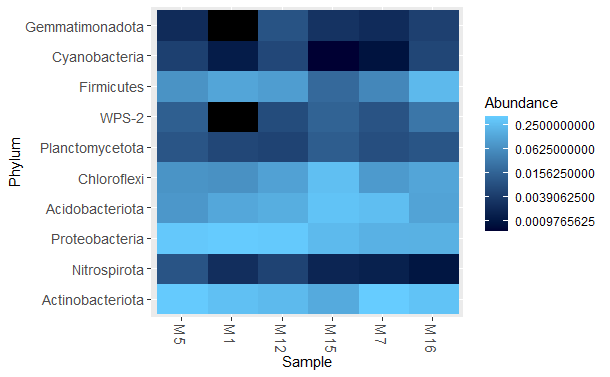

```r
plot_heatmap(Top_phyla, taxa.label = "Phylum")
```

## ANALISIS TAXONOMICO

```r
library(phyloseq)
library(tidyverse)
library(dplyr)
library(RColorBrewer)
library(pheatmap) # Heatmaps
library(microbiome)
library(ggsignif)
library(scales) # Modificar escalas
library(car)
library(wesanderson)
```

# VISUALIZACIÓN A NIVEL PHYLUM

# Heatmap

```r
colnames(OTU_matrix) <- Tax_matrix$Phylum
```

```
Error: objeto 'OTU_matrix' no encontrado
```

# PROCESAMIENTO DE DATOS

# Heatmap analisis taxonomico

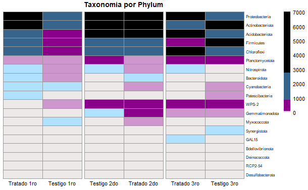

## Graficos de barras

Se acuerdan que al ver las funciones que nos daba phyloseq vimos como hacer graficos de barras?, pues bueno ahora vamos a aprender a hacerlos bonitos:

# Pre- procesamiento de datos

### El grafrico

Usando la funcion plot_composition que viene del paquete microbiome CUANDO USAMOS GGPLOT TODO SE UNE CON + CUANDO USAMOS HEATMAP SE UNE CON ,

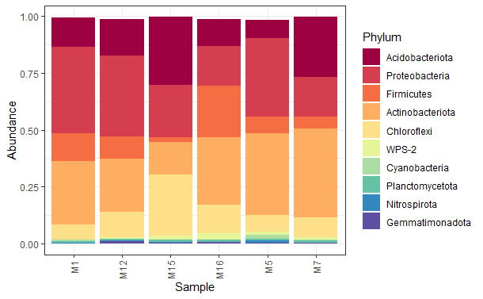

Si bien este grafico ya es hermoso, la forma mas simple de representar abundancia relativa es con porcentajes. Asi que les voy a ensenar la formula de scales te modifica etso facilmente

```r
plot_composition(Top_phyla,plot.type = "barplot")+
  theme_bw()+
  ggtitle("Abundancias relativas a nivel Phylum")+
  theme(plot.title = element_text(hjust = 0.5, size = 15, face = "bold"))+
  xlab("Muestras")+
  ylab("Abundancia")+
  scale_fill_brewer(palette = "Spectral", name = "Phylum",
                    labels=c("Acidobacteriota", "Proteobacteria", "Firmicutes", "Actinobacteriota", "Chloroflexi", "WPS-2","Cyanobacteria","Planctomycetota","Nitrospirota","Gemmatimonadota"))+
  scale_x_discrete(labels=c("Tratado 1ro","Tratado 2do","Tratado 3ro","Testigo 3ro","Testigo 1ro","Testigo 2do"))+
  guides(x=guide_axis(angle=0))+
  scale_y_continuous(breaks = pretty_breaks(n = 10),# numero de separaciones
                     labels = scales::percent)# representadas en %
```

[output not shown]

Usando estos dos graficos que pueden conclur de sus datos? Hay algun phylum que crean que vale la pena revisar a detalle?

Proteocateria y actinobacteriota por abundancias Chloroflexi y Firmicutes por diferencias entre tratamientos

Si bien ya les enseñe a presentar graficos bonitos y definitivamente cualquiera de estos graficos podrian incluirlo en un reporte, la visualizacion tambien nos permite darnos cuenta si existen ciertos patrones en abundancia. De esta manera podemos seleccionar alguno de estos grupos y verlos en la lupa de una manera mas minuciosa.

# ANALISIS NIVEL PHYLUM

Para los graficos ya habiamos extraido nuestras tablas de conteos y taxa, pero ahora tambien necesitamos nuestros metadatos

# Pre pocesamiento de datos …esto no se corre a menos que no tengas corrido o de arriba…

```r
# Shapiro test
for (i in 3:ncol(Bio_phyla)) {
  shapiro <- shapiro.test(Bio_phyla[,i])
  normal <- ifelse(shapiro[["p.value"]]>0.05,"YES", "NO")
  print(c(i,normal))
}
```

```
[1] "3"   "YES"
[1] "4"   "YES"
[1] "5"   "YES"
[1] "6"   "YES"
[1] "7"   "YES"
[1] "8"   "YES"
[1] "9"   "YES"
[1] "10"  "YES"
[1] "11"  "YES"
[1] "12"  "YES"
[1] "13"  "YES"
[1] "14" "NO"
[1] "15" "NO"
[1] "16" "NO"
[1] "17" "NO"
[1] "18" "NO"
[1] "19" "NO"
[1] "20" "NO"
[1] "21" "NO"
```

## SEGUIMOS CON ANOVA

```r
### For loop de t.test
# paso 1.- tabla vacia
Bio_pvalues <- data.frame(Tratamiento = rep(NA,11),
                            Muestreo = rep(NA,11)) # en la tabla de norm_bio o bien la ultima el total de columnas menos las dos priemras por ser las variables independientes...en este caso son 13-2 = 11

# paso 1.5.- ver si se pueden meter valores por columna
objeto_T <- t.test(Proteobacteria ~ Tratamiento, data = vid_stats)# cambiar vid_stats por el objeto de este ejercicio...
# aqui vimos como llamar al p.value = objeto_T[["p.value"]]
#otra manera de ver si se puede es asi:
#t.test(vid_stats[,3] ~ Tratmiento, data= vid_stats)

# paso 2.- for loop
for (i in 3:ncol(Norm_Bio)) {
  T_trat <- t.test(Norm_Bio[,i] ~ Tratamiento, data = Norm_Bio)
  S_trat <- Anova(aov(Norm_Bio[,i] ~ Muestreo, data = Norm_Bio))
  j <- i-2 # para que empiece a llenar desde la fila 1 osea i in 3, i-2 osea 1
  Bio_pvalues$Tratamiento[j] <- T_trat[["p.value"]]# para t.test
  Bio_pvalues$Muestreo[j] <- S_trat$`Pr(>F)`[1]#para anova en los corchetes es el num de muestreo con anova
}

# paso 3.- poner los nombres
row.names(Bio_pvalues) <- colnames(Norm_Bio[3:13])

# paso 4.- guardar tabla
write.csv(Bio_pvalues, "~/RStudio/CursoInnovak/Agronomia/Materiales/Bio_pvalue.csv")
```

## Visualización a nivel orden

```r
# Barplot
plot_composition(Proteo_or,plot.type = "barplot")+
  theme_bw()+
  ggtitle("Abundancias de Proteobacteria a nivel Orden")+
  theme(plot.title = element_text(hjust = 0.5, size = 15, face = "bold"))+
  scale_x_discrete(labels=c("Tratado 1ro","Tratado 2do","Tratado 3ro","Testigo 3ro","Testigo 1ro","Testigo 2do"))+
  xlab("Muestras")+
  ylab("Abundancia")# IFOMB8332W = Rhizobiales,
```

[output not shown]

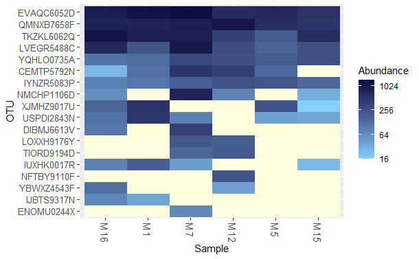

```r
plot_heatmap(Actino_or,
             low = "lightskyblue", high = "#0F0F43",
             na.value = "lightyellow",
             taxa.order = names(sort(taxa_sums(Actino_or))))
```

# Estadistico Nivel Orden

```r
# Volvemos a correr shapiro
for (i in 1:ncol(Norm_Bio)) {
  shapiro <- shapiro.test(Norm_Bio[,i])
  normal <- ifelse(shapiro[["p.value"]]>0.05,"YES", "NO")
  print(c(i,normal))
}
```

```
[1] "1"   "YES"
[1] "2"   "YES"
[1] "3"   "YES"
[1] "4"   "YES"
```

```r
for (i in 1:ncol(Norm_Bio)) {
  shapiro <- shapiro.test(Norm_Bio[,i])
  normal <- ifelse(shapiro[["p.value"]]>0.05,"YES", "NO")
  print(c(i,normal))
}
```

```
[1] "1"  "NO"
[1] "2"  "NO"
[1] "3"  "NO"
[1] "4"  "NO"
[1] "5"  "NO"
```

# Visualización a nivel Genero / Especie

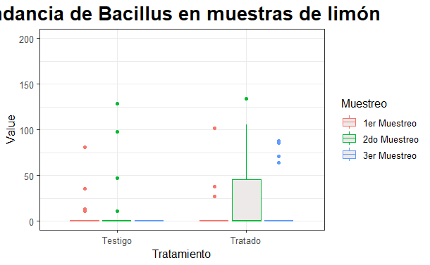

# Diversidad alfa

```r
estimate_richness(Bio, split = TRUE,
                  measures = c("Observed", "Chao1", "Shanoon", "Simpson"))
```

|  | Observed | Chao1 | se.chao1 | Simpson |
| --- | --- | --- | --- | --- |
| M1 | 182 | 182 | 0 | 0.9872113 |
| M12 | 209 | 209 | 0 | 0.9922897 |
| M15 | 171 | 171 | 0 | 0.9885463 |
| M16 | 211 | 211 | 0 | 0.9844573 |
| M5 | 101 | 101 | 0 | 0.9830752 |
| M7 | 221 | 221 | 0 | 0.9892109 |

# Graficando diversidad alfa

```r
leveneTest(Chao1~ Tratamiento * Muestreo, # vari. indep
                       data = alphadiv)
```

```
Levene's Test for Homogeneity of Variance (center = median)
      Df F value Pr(>F)
group  5     NaN    NaN
       0
```

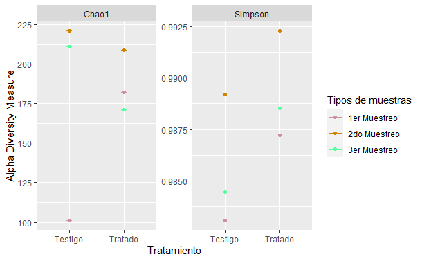

```r
# Grafico usando funcion de phyloseq
plot_richness(Bio,
              x= "Tratamiento",
              measures = c("Simpson","Chao1"),
              color = "Muestreo") +
  scale_color_manual(values = c("pink3","orange3","seagreen1"),
                     name = "Tipos de muestras",
                     labels = c("1er Muestreo","2do Muestreo","3er Muestreo")) +
  theme_gray()
```

# Analisis estadistico

Como con los datos que vimos durante el modulo estadistico, el analisis estadistico seguira el mismo flujo de trabajo que vimos y lo debran elegir dependiendo de su numero de muestras, tratamientos, etc.

```r
## Primero revisamos normaliad

# Shapiro
for (i in 3:16) { # cambia dependiendo de sus datos
  shapiro <- shapiro.test(alphadiv[,i])
  normal <- ifelse(shapiro[["p.value"]]>0.05, "YES", "NO")
  print(c(i,normal))
}

# histogramas; si es que no eran normales
for (i in 3:16) {
  hist(alphadiv[,i],
       main = 1)
}
```

Dado que yo tengo 2 tipos de variables independientes (tratamientos y tipos de planta), para mi analisis usare una ANOVA de 2 vias: “esto es en el caso de Isabel osea con sus muestras, en nuestro caso solo tenemos una muestra por persona por lo cual no podriamos usar un ANOVA de 2 vias”

```r
## Revisar homogeneidad de varianza

for(i in 3:col(alphadiv)){ # empieza en la col que terminan metadatos
  Lev_ex <- leveneTest(alphadiv[,i]~ Tratamiento * Suelo, # vari. indep
                       data = alphadiv)
  levene <- ifelse(Lev_ex[["Pr(>F)"]]>0.05, "YES", "NO")
  print(c(i,levene))
}

leveneTest(Observed~ Tratamiento * Suelo, # vari. indep
                       data = alphadiv)
# Como solo tenemos una muestra no hay varianza por lo que no se puede calcular el test levene
```

## Analisis Funcional

# Pre- procesamiento de datos

Antes que nada tenemos que preparar los datos par asubirlo al servidor:

1.- Primero que nada tenemos que aglomerar los datos por genero (genus) porque el software no acepta identificacion taxonomica repetida:

# Trabajando con los datos descargados

## Subir datos

# Pre-procesamiento de datos

```r
metabolismo <- metabolismo[ , sorder]
```

```
Error in `[.data.frame`(metabolismo, , sorder) :
  undefined columns selected
```

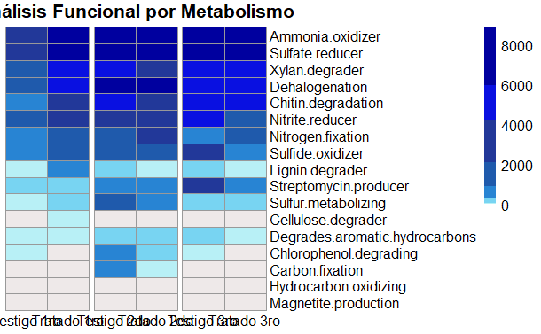

### Energia

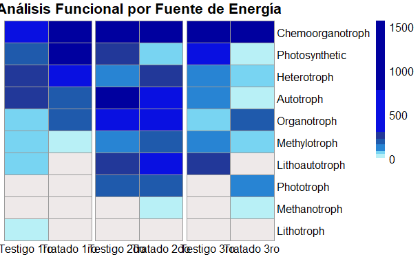

El proceso de analisis es exactamente igual al que usamos para el analisis taxonomico

# Resultado estadistico metabolismo

```r
for (i in 3:ncol(Norm_metab)) {
  shapiro <- shapiro.test(Norm_metab[,i])
  normal <- ifelse(shapiro[["p.value"]]>0.05,"YES", "NO")
  print(c(i,normal))
} #otra vez
```

```
[1] "3"   "YES"
[1] "4"   "YES"
[1] "5"   "YES"
```

# Resultados estadisticos energia

```r
for (i in 3:ncol(stats)) {
  T_trat <- t.test(stats[,i] ~ Tratamiento, data = stats)
  S_trat <- Anova(aov(stats[,i] ~ Muestreo, data = stats))
  j <- i-2 # para que empiece a llenar desde la fila 1 osea i in 3, i-2 = 1
  ener_pvalues$Tratamiento[j] <- T_trat[["p.value"]]
  ener_pvalues$Muestreo[j] <- S_trat$`Pr(>F)`[1]
}
```

```
Error: objeto 'stats' no encontrado
```

# Graficos solicitados por Fco…

[figure not shown]